# Project: Guide the four-axis aircraft learning

### random Agent

```python
import  random

class Basic_Agent():
    def __init__(self, task):
        self.task = task

    def act(self):
        new_thrust = random.gauss(450., 25.)
        return [new_thrust + random.gauss(0., 1.) for x in range(4)]
```

Run the code below to let the agent specify the action to control the quadcopter.

Please free to change our offer `runtime`, `init_pose`, `init_velocities`and `init_angle_velocities`values to change the initial conditions of a four-axis aircraft.

The bottom of the `labels`list as a comment simulation data. All information is stored in `data.txt`the document, and save it in `results`the directory.

```python
% load_ext autoreload
 % autoreload 2

import csv
import numpy as np
from task import Task

# Modify the values below to give the quadcopter a different starting position.
runtime = 5.                                     # time limit of the episode
init_pose = np.array([0., 0., 10., 0., 0., 0.])  # initial pose
init_velocities = np.array([0., 0., 0.])         # initial velocities
init_angle_velocities = np.array([0., 0., 0.])   # initial angle velocities
file_output = 'data.txt'                         # file name for saved results

# Setup
task = Task(init_pose, init_velocities, init_angle_velocities, runtime)
agent = Basic_Agent(task)
done = False
labels = ['time', 'x', 'y', 'z', 'phi', 'theta', 'psi', 'x_velocity',
          'y_velocity', 'z_velocity', 'phi_velocity', 'theta_velocity',
          'psi_velocity', 'rotor_speed1', 'rotor_speed2', 'rotor_speed3', 'rotor_speed4']
results = {x : [] for x in labels}

# Run the simulation, and save the results.
with open(file_output, 'w') as csvfile:
    writer = csv.writer(csvfile)
    writer.writerow(labels)
    while True:
        rotor_speeds = agent.act()
        _, _, done = task.step(rotor_speeds)
        to_write = [task.sim.time] + list(task.sim.pose) + list(task.sim.v) + list(task.sim.angular_v) + list(rotor_speeds)
        for ii in range(len(labels)):
            results[labels[ii]].append(to_write[ii])
        writer.writerow(to_write)
        if done:
            break
```

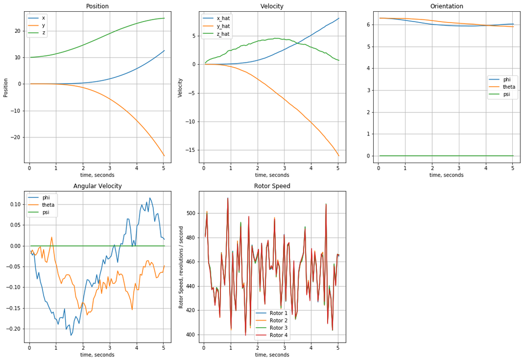

```python
plot_run(results)
```

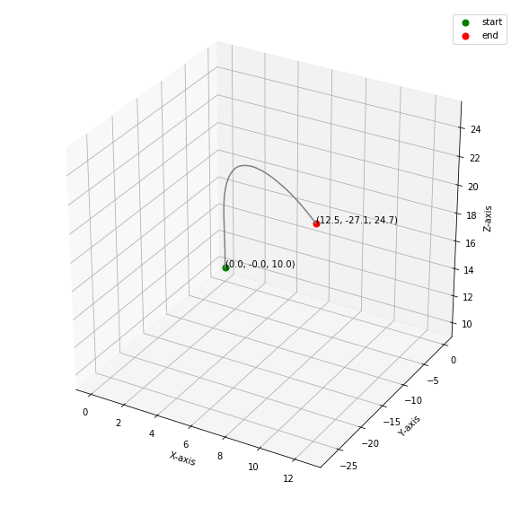

```python
path = [[results['x'][i], results['y'][i], results['z'][i]] for i in range(len(results['x']))]
show_flight_path(path, target=None)
```

Before you specify a task, you need to derive the state of the environment in the simulator. Run the code below to output the following variable values at the end of the simulation:

- `task.sim.pose`: Four-way aircraft at ( $x,y,z$) The position in the coordinate system and the Euler angle.
- `task.sim.v`: Quadcopter in ( $x,y,z$) The speed in the coordinate system.
- `task.sim.angular_v`: Radius of three Euler angles per second.

```python
# the pose, velocity, and angular velocity of the quadcopter at the end of the episode
print(task.sim.pose)
print(task.sim.v)
print(task.sim.angular_v)
```

```
[ 12.53793773 -27.05667129 24.71770869 6.01897845 5.89467343 0. ]
[ 8.07873718 -16.00327905 0.70099963]
[ 0.01539283 -0.04806114 0. ]
```

In the `task.py`task of examples, we use six dimensions of action to build a four-axis aircraft environmental status of each time step. However, you can also change the task as you wish. You can add speed information to expand the state vector, or use any combination of motion, velocity, and angular velocity to construct an environment state that is appropriate for your task.

## Task

In the `task.py`middle, we provide an example of a task for you. Please open this file in a new window.

Use `__init__()`method to initialize specify several variables needed for this task.

- As the simulator `PhysicsSim`classes (from `physics_sim.py`example file) is initialized.
- Inspired by the research methods in the DDPG paper, we used a method of repeatedly calling actions. For each time step agent, we will use the `action_repeats`time step to simulate. If you are not familiar with this approach, you can read the conclusions of the [DDPG paper](https://arxiv.org/abs/1509.02971) .
- We set the value of each component in the state vector. In the task example, we only set the action information for six dimensions. In order to set the vector size ( `state_size`), we must consider repeated actions.
- The task environment is usually a four-dimensional action space with one input ( `action_size=4`) per axis . You can set the minimum ( `action_low`) and maximum ( `action_high`) values for each input .
- The task examples we provide in the file will bring the agent to the target location. We set the target location to a variable.

`reset()`The method will reset the simulator. This method is called by the agent whenever the phase ends. You can see the examples in the code below.

`step()`The method is the most important one. It will receive the action selected by the agent `rotor_speeds`and prepare for the next state, returning to the agent. Then, you will pass `get_reward()`calculated reward value. This phase will be considered complete when the specified time is exceeded or when the quadcopter reaches the edge of the simulator.

Next, you'll learn how to test the performance of the agent in this task.

## Agent

`agents/policy_search.py`The example of the agent provided in the file uses a very simple linear strategy that treats the motion vector directly as a dot product of the state vector and the matrix weight. It then randomly interferes with the parameters by adding some Gaussian noise to produce different strategies. Based on the average reward value ( `score`) obtained at each stage , it will record the best set of parameters found so far and the state of change of the score, and adjust the scale factor accordingly to increase or decrease the noise.

Please run the code below to see the performance of the agent in the task example.

```python
import sys
import pandas as p
```

```python
from agents.policy_search import PolicySearch_Agent
from task import Task

labels = ['time', 'x', 'y', 'z', 'phi', 'theta', 'psi', 'x_velocity',
          'y_velocity', 'z_velocity', 'phi_velocity', 'theta_velocity',
          'psi_velocity', 'rotor_speed1', 'rotor_speed2', 'rotor_speed3', 'rotor_speed4']
results = {x : [] for x in labels}

num_episodes = 1
target_pos = np.array([0., 0., 10.])
task = Task(target_pos=target_pos)
agent = PolicySearch_Agent(task)

for i_episode in range(1, num_episodes+1):
    state = agent.reset_episode() # start a new episode
    while True:
        action = agent.act(state)
        next_state, reward, done = task.step(action)
        if i_episode == num_episodes:
            to_write = [task.sim.time] + list(task.sim.pose) + list(task.sim.v) + list(task.sim.angular_v) + list(action)
            for ii in range(len(labels)):
                results[labels[ii]].append(to_write[ii])
        agent.step(reward, done)
        state = next_state
        if done:
            print("\rEpisode = {:4d}, score = {:7.3f} (best = {:7.3f}), noise_scale = {}".format(
                i_episode, agent.score, agent.best_score, agent.noise_scale), end="")  # [debug]
            break
    sys.stdout.flush()
```

```
Episode =    1, score =  -0.993 (best =  -0.993), noise_scale = 0.05
```

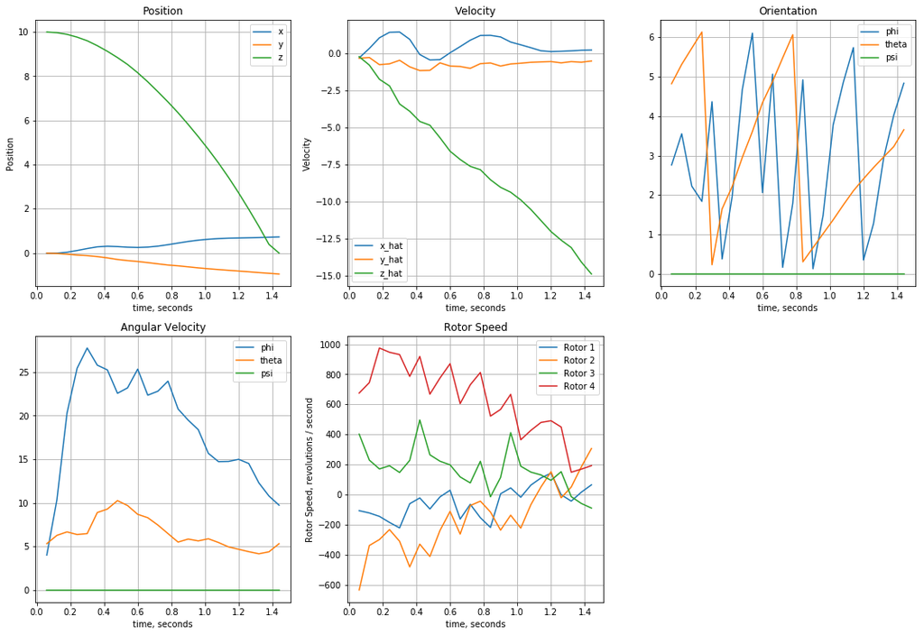

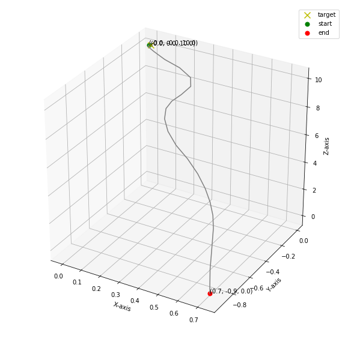

```python
plot_run(results)

path = [[results['x'][i], results['y'][i], results['z'][i]] for i in range(len(results['x']))]
show_flight_path(path, target=target_pos)
```

The performance of this agent must be very bad! Now it is your turn to play!

## Define tasks, design and train your agents!

Modify the `task.py`file to specify the task of your choice. If you are not sure what to choose, you can teach your quadcopter to take off, hover, land or reach a designated location.

After the specified task, `agents/policy_search.py`Agent example as a template to in `agents/agent.py`the definition of your own intelligence body. You can freely borrowed elements you need from the agent examples, including how to modularize your code (use `act()`, `learn()`and `reset_episode_vars()`other auxiliary methods).

Please note that the first agent and task you specify will **most likely** not be able to learn smoothly. You will need to improve the different hyperparameters and reward functions until you get good results.

When developing an agent, you also need to pay attention to its performance. Refer to the code below to establish a mechanism to store the total reward value for each stage. If the stage reward value is gradually increasing, your agent is learning.

```python
# From Udacity
import numpy as np
import random
from collections import namedtuple, deque
from agents.agent import *
from task import *
```

```python
labels = ['time', 'x', 'y', 'z', 'phi', 'theta', 'psi', 'x_velocity',
          'y_velocity', 'z_velocity', 'phi_velocity', 'theta_velocity',
          'psi_velocity', 'rotor_speed1', 'rotor_speed2', 'rotor_speed3', 'rotor_speed4']
results = {x : [] for x in labels}

labels2 = ['epoch', 'reward']
results2 = {x: [] for x in labels2}

runtime = 5.0                                    # time limit of the episode
init_pose = np.array([0., 0., 10., 0., 0., 0.])  # initial pose
init_velocities = np.array([0., 0., 0.])         # initial velocities
init_angle_velocities = np.array([0., 0., 0.])   # initial angle velocities
target_pos = np.array([0., 0., 10.])

# Setup
task = Task(init_pose=init_pose, init_velocities=init_velocities,
        init_angle_velocities=init_angle_velocities, runtime=runtime, target_pos=target_pos) #, init_velocities, init_angle_velocities, runtime
agent = DDPG(task)
best_reward = None
i_episode = 0
```

```python
from tqdm import tqdm_notebook as tqdm

num_episodes = 2000
try:
    to_write = None
    pbar = tqdm(range(1, num_episodes+1))
    for i_episode_now in pbar:
        i_episode = i_episode+1
        state = agent.reset_episode() # start a new episode
        current_reward = 0
        time = 0
        while True:
            time = time +1
            action = agent.act(state)
            next_state, reward, done = task.step(action)

            """Update Reward"""
            current_reward = current_reward+reward
            """Write Final Result"""
            to_write = [task.sim.time] + list(task.sim.pose) + list(task.sim.v) + list(task.sim.angular_v) + list(action)
            if i_episode_now == num_episodes:
                for ii in range(len(labels)):
                    results[labels[ii]].append(to_write[ii])

            agent.step(action, reward, next_state, done) # add action, next_state
            state = next_state
            if done:
                if best_reward == None or current_reward > best_reward:
                    best_reward = current_reward
                pbar.set_description("\rEpisode = {:4d}/{:4d}, score = {:7.3f}/{:3.3f} (best = {:7.3f}) z={:.3f}, v={:.3f}".format(
                    i_episode_now, i_episode, current_reward, current_reward/time, best_reward, task.sim.pose[2], task.sim.v[2]))
                break

        to_write2 = [i_episode] + [current_reward]
        for iii in range(len(labels2)):
            results2[labels2[iii]].append(to_write2[iii])

        sys.stdout.flush()
except KeyboardInterrupt as e:
    for ii in range(len(labels)):
        results[labels[ii]].append(to_write[ii])
```

## Drawing stage

Please plot the total rewards that the agent gets in each phase, which can be a single run bonus value or an average of multiple runs.

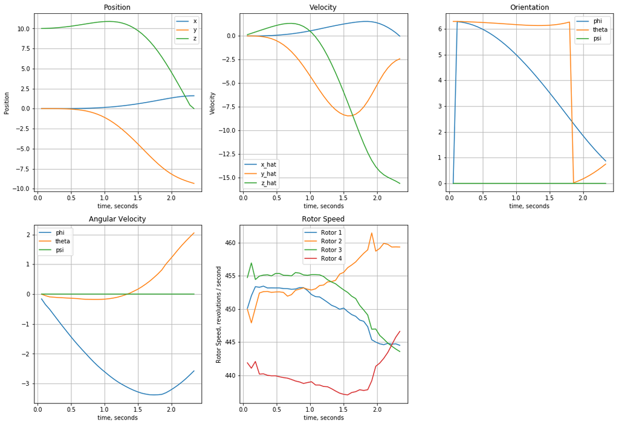

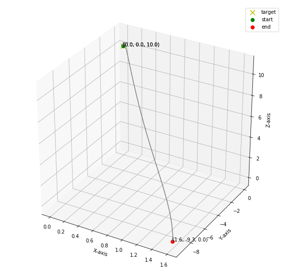

```python
# ## TODO: Plot the rewards.

# import matplotlib.pyplot as plt
# %matplotlib inline

# plt.plot(results['episod'], results['total_reward'])
# #plt.legend()

# _ = plt.ylim()
plot_run(results)

path = [[results['x'][i], results['y'][i], results['z'][i]] for i in range(len(results['x']))]
show_flight_path(path, target=target_pos)
```

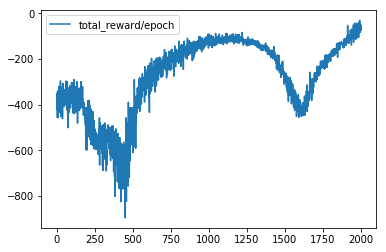

```python
plt.plot(results2['epoch'], results2['reward'], label='total_reward/epoch')
# plt.yscale('log')
plt.legend()
plt.show()
```

```python
smooth_value = int(len(results2['reward']) * 0.01)
smoothed = np.convolve(results2['reward'], np.ones(smooth_value)/smooth_value)
# smoothed = smooth(results2['reward'] ,window_len=smooth_value,window='hanning')
x = list(range(len(smoothed))) #results2['epoch']
plt.plot(x[:-10], smoothed[:-10], label='total_reward/epoch')
plt.legend()
plt.show()
```

[output not shown]

```python
# Storage
%store task
%store agent
%store results
%store results2
%store best_reward
%store i_episode
```